# Basic Web Crawling Project: Crawl, Clean, and analyze data from a *static* HTML page

###### Created by: Michael Gagliano on 9/25/2018

###### "K-State Honor Code "On my honor, as a student, I have neither given nor received unauthorized aid on this academic work.

### https://www.indeed.com/cmp/Kansas-State-University/reviews

The website was chosen due to the familiarity with the context of the data, and the ability to more effectively sift through the noise/irrelevant data. I chose Indeed.com instead of the increasingly-popular Glassdoor.com due to Glassdoor already indicating if the review is Positive/Negative based on the posted "Recommends/Does Not Recommend" feature.

## Questions to Answer:

- What is the breakdown of reviews left?
- What is the breakdown of reviews left by the most commonly reviewed Title?
- Do text analytics provide any particular further insight into what is frequently discussed in the reviews?
- Limitations?

## Web Scraping (Most recent 210 reviews)

To reduce the server-traffic load I am only scraping the most recent 200 of 300-and-some reviews

```python
import requests as req #Pulls the data via URL
from lxml import html #Xpath manipulation
import csv #Allows .csv files to be read/saved
import pandas as pd #Primary tool for data manipulation
import re #Regular Expression to target specific parent:child nodes
```

```python
alldata =[]

web = "https://www.indeed.com/cmp/Kansas-State-University/reviews?start=%s" #20 reviews per page == 10 pages

alldata =[]

for page in range(0, 200, 20):
    url = web % page
    data = html.fromstring(req.get(url).text)
#xpath
    for i in data.xpath('//div[@class="cmp-review"]'):
        name = i.xpath('div/div/span/span[@class="cmp-reviewer"]/text()')
        location = i.xpath('div/div/span[@class="cmp-reviewer-job-location"]/text()')

##-- SEE NOTES BELOW ABOUT THE FOLLOWING XPATH
        rating = i.xpath('div/div/span/meta/@content')
##-- Rating was not populating all 210 values from the original xpath for unknown reasons.
##-- Calling a more general xpath pulled all numerical values in correct indexed positions,\
##-- but additional cleanup will be necessary.

        review = i.xpath('div/div/span[@class="cmp-review-text"]/text()')
        date = i.xpath('div/div/span[@class="cmp-review-date-created"]/text()')
        #print(name, location, rating, review, date)
        alldata.append([name, location, rating, review, date])

len(alldata)
```

```
210
```

Setting the data loaded into the no-longer-empty 'alldata' list type variable and saving it as a csv. This will help especially in the event I don't want/need to modify the xpath parameters once they're set (which I shouldn't need to). Calling the data locally will be far more efficient going forward.

```python
df = pd.DataFrame(alldata)
df.to_csv('KSUindeedscrape_not_clean.csv')
df.info()
```

```
<class 'pandas.core.frame.DataFrame'>
RangeIndex: 210 entries, 0 to 209
Data columns (total 5 columns):
0    210 non-null object
1    210 non-null object
2    210 non-null object
3    210 non-null object
4    210 non-null object
dtypes: object(5)
memory usage: 8.3+ KB
```

```python
df.head()
```

|  | 0 | 1 | 2 | 3 | 4 |
| --- | --- | --- | --- | --- | --- |
| 0 | [Assistant Director of Admissions and Financia... | [Manhattan, KS] | [5, Assistant Director of Admissions and Finan... | [Management gives notice to employee and appre... | [September 16, 2018] |
| 1 | [Graduate Teaching Assistant] | [Manhattan, KS] | [5, Graduate Teaching Assistant] | [I worked as a Graduate Teaching Assistant (GT... | [September 6, 2018] |
| 2 | [Instructor, Italian] | [Manhattan, KS] | [3, Instructor, Italian] | [I loved teaching Italian at K-State. It was ... | [August 27, 2018] |
| 3 | [County Extension Director] | [Atwood, KS] | [4, County Extension Director] | [County Extension Director. Responsible for al... | [August 25, 2018] |
| 4 | [Custodial Worker] | [Manhattan, KS] | [4, Custodial Worker] | [In my case, the most enjoyable part of my wor... | [August 22, 2018] |

Each element of the data scraped is parsed with brackets; Let's get rid of those. We'll also do the same for the apostrophes following.

```python
#Removing the brackets
df[0] = df[0].astype(str).str.replace('\[|\]', '')
df[1] = df[1].astype(str).str.replace('\[|\]', '')
df[2] = df[2].astype(str).str.replace('\[|\]', '')
df[3] = df[3].astype(str).str.replace('\[|\]', '')
df[4] = df[4].astype(str).str.replace('\[|\]', '')
df.head()
```

|  | 0 | 1 | 2 | 3 | 4 |
| --- | --- | --- | --- | --- | --- |
| 0 | 'Assistant Director of Admissions and Financia... | 'Manhattan, KS' | '5', 'Assistant Director of Admissions and Fin... | 'Management gives notice to employee and appre... | 'September 16, 2018' |
| 1 | 'Graduate Teaching Assistant' | 'Manhattan, KS' | '5', 'Graduate Teaching Assistant' | 'I worked as a Graduate Teaching Assistant (GT... | 'September 6, 2018' |
| 2 | 'Instructor, Italian' | 'Manhattan, KS' | '3', 'Instructor, Italian' | "I loved teaching Italian at K-State. It was ... | 'August 27, 2018' |
| 3 | 'County Extension Director' | 'Atwood, KS' | '4', 'County Extension Director' | 'County Extension Director. Responsible for al... | 'August 25, 2018' |
| 4 | 'Custodial Worker' | 'Manhattan, KS' | '4', 'Custodial Worker' | 'In my case, the most enjoyable part of my wor... | 'August 22, 2018' |

```python
df[0] = df[0].str.replace(r'\'','')
df[1] = df[1].str.replace(r'\'','')
df[2] = df[2].str.replace(r'\'','')
df[3] = df[3].str.replace(r'\'','')
df[4] = df[4].str.replace(r'\'','')
df.head()
```

|  | 0 | 1 | 2 | 3 | 4 |
| --- | --- | --- | --- | --- | --- |
| 0 | Assistant Director of Admissions and Financial... | Manhattan, KS | 5, Assistant Director of Admissions and Financ... | Management gives notice to employee and apprec... | September 16, 2018 |
| 1 | Graduate Teaching Assistant | Manhattan, KS | 5, Graduate Teaching Assistant | I worked as a Graduate Teaching Assistant (GTA... | September 6, 2018 |
| 2 | Instructor, Italian | Manhattan, KS | 3, Instructor, Italian | "I loved teaching Italian at K-State. It was ... | August 27, 2018 |
| 3 | County Extension Director | Atwood, KS | 4, County Extension Director | County Extension Director. Responsible for all... | August 25, 2018 |
| 4 | Custodial Worker | Manhattan, KS | 4, Custodial Worker | In my case, the most enjoyable part of my work... | August 22, 2018 |

Renaming the column names and deleting the duplicate'featured' review on each page-

```python
df.rename(columns={0: 'Title', 1: 'Loc', 2: 'Rating', 3: 'Review', 4: 'Date'}, inplace=True)
df = df.drop_duplicates(keep='first')
df
#Dropping the first featured review that appears at the top of each page
#resetting the index so there is not gap from the deleted rows
```

|  | Title | Loc | Rating | Review | Date |
| --- | --- | --- | --- | --- | --- |
| 0 | Assistant Director of Admissions and Financial... | Manhattan, KS | 5, Assistant Director of Admissions and Financ... | Management gives notice to employee and apprec... | September 16, 2018 |
| 1 | Graduate Teaching Assistant | Manhattan, KS | 5, Graduate Teaching Assistant | I worked as a Graduate Teaching Assistant (GTA... | September 6, 2018 |
| 2 | Instructor, Italian | Manhattan, KS | 3, Instructor, Italian | "I loved teaching Italian at K-State. It was ... | August 27, 2018 |
| 3 | County Extension Director | Atwood, KS | 4, County Extension Director | County Extension Director. Responsible for all... | August 25, 2018 |
| 4 | Custodial Worker | Manhattan, KS | 4, Custodial Worker | In my case, the most enjoyable part of my work... | August 22, 2018 |
| 5 | A&P Mechanic | Salina, KS | 4, A&P Mechanic | I appreciated the opportunity K-State provided... | August 3, 2018 |
| 6 | Administrative Specialist | Manhattan, KS | 3, Administrative Specialist | It’s a job! But no advancement opportunities f... | August 3, 2018 |
| 7 | Group Visit Coordinator - New Student Services | Manhattan, KS | 5, Group Visit Coordinator - New Student Services | It was a great place to work, flexible hours, ... | August 3, 2018 |
| 8 | Boiler Plant Operator | Manhattan, KS | 5, Boiler Plant Operator | This was an excellent job for a student attend... | July 23, 2018 |
| 9 | Cashier/Barista Quick Cats | Manhattan ks | 4, Cashier/Barista Quick Cats | As a student it was a fun work environment . T... | July 1, 2018 |
| 10 | Student Services Coordinator | Fort Riley, Kansas | 5, Student Services Coordinator | K-State Global campus is a great place to work... | June 28, 2018 |
| 11 | Adjunct Instructor | Manhattan, KS | 4, Adjunct Instructor | Good place to work, especially as an adjunct p... | June 19, 2018 |
| 12 | Research Associate | Manhattan, KS | 4, Research Associate | Good research and study environment. No traffi... | June 15, 2018 |
| 13 | Stadium Usher | Manhattan, KS | 5, Stadium Usher | I enjoyed working during the football games. ... | June 11, 2018 |
| 14 | Research Assistant Professor | Manhattan, KS | 4, Research Assistant Professor | Skillfully focused on wheat and developing mol... | June 6, 2018 |
| 15 | Custodial Specialist | Manhattan, KS | 1, Custodial Specialist | During school a typical week is cleaning the c... | June 6, 2018 |
| 16 | Teaching Assistant | Manhattan, KS | 4, Teaching Assistant | Very nice work environment. People are pleasan... | June 5, 2018 |
| 17 | Industrial Engineering Mentor | Manhattan, KS | 5, Industrial Engineering Mentor | At Kansas State University everyone is very wi... | June 4, 2018 |
| 18 | Graduate Assistant | Manhattan, KS | 5, Graduate Assistant | "small town, typically college town experience... | June 1, 2018 |
| 19 | Research Assistant | Manhattan, KS | 4, Research Assistant | I was a research assistant at Kansas State for... | May 24, 2018 |
| 20 | Campus Representative | Manhattan, KS | 5, Campus Representative | Wonderful company to work for! They will set y... | May 23, 2018 |
| 22 | Adjunct Instructor | Salina, KS | 2, Adjunct Instructor | A few poisonous faculty members (who were over... | May 21, 2018 |
| 23 | Office Assistant | Manhattan, KS | 4, Office Assistant | "Did a lot of correspondence, date entry, answ... | May 21, 2018 |
| 24 | Facility Attendant | Manhattan, KS | 5, Facility Attendant | The workplace culture is great, everyone wants... | May 21, 2018 |
| 25 | Research and Teaching Assistant | Manhattan, KS | 5, Research and Teaching Assistant | Good place to work, live, and raise kids. Stud... | May 15, 2018 |
| 26 | Post-Doctoral Research and Teaching Associate | Manhattan, KS 66506 | 5, Post-Doctoral Research and Teaching Associate | It was fun and wonderful work place. Daily wo... | April 29, 2018 |
| 27 | Teaching Assistant | Manhattan, KS | 5, Teaching Assistant | Was just a teaching assistant for cultural ant... | April 26, 2018 |
| 28 | Lab Technician | Salina, KS | 5, Lab Technician | This job was an excellent opportunity to entry... | April 24, 2018 |
| 29 | Usher | Manhattan, KS | 5, Usher | I enjoyed working here for the most part, beca... | April 22, 2018 |
| 30 | Community Assistant (CA) | Manhattan, KS | 4, Community Assistant (CA) | It was fun knowing all of the dining hall resi... | April 6, 2018 |
| ... | ... | ... | ... | ... | ... |
| 179 | Research Assistant | Manhattan, KS | 5, Research Assistant | Nice campus, cheap housing, friendly environme... | May 19, 2016 |
| 180 | Graduate Research Assistant | Manhattan, KS | 5, Graduate Research Assistant | Good Management and growth and learning opport... | May 10, 2016 |
| 181 | Accomplishments | Manhattan, KS | 5, Accomplishments | All of this work was mostly voluntary, but the... | May 3, 2016 |
| 182 | Volunteer Consultant | Manhattan, KS | 5, Volunteer Consultant | I really enjoy the work I do with the officers... | May 3, 2016 |
| 183 | "Teachers Aide" | Manhattan, KS | 4, "Teachers Aide" | I enjoyed my time at the KSU Child Development... | May 2, 2016 |
| 184 | Graduate Teaching Assistant (GTA) | Manhattan, KS | 5, Graduate Teaching Assistant (GTA) | "As a graduate teaching assistant my work resp... | May 1, 2016 |
| 185 | Student Office Assistant | Manhattan, KS | 4, Student Office Assistant | Great atmosphere, a little outdated in office ... | May 1, 2016 |
| 186 | Research Assistant (Volunteer) | Manhattan, KS | 5, Research Assistant (Volunteer) | K-State provides outstanding opportunities to ... | April 14, 2016 |
| 187 | Research Associate | Manhattan, KS | 3, Research Associate | Mediocre at best I would certainly not recomme... | April 4, 2016 |
| 188 | Solutions Room Technician | Manhattan, KS | 5, Solutions Room Technician | Many of my tasks had weekly deadlines and if w... | March 23, 2016 |
| 190 | Administrative Assistant | Manhattan, KS | 5, Administrative Assistant | The job was great. We were busy, helpful with ... | March 11, 2016 |
| 191 | Peer Advisor | Manhattan, KS | 2, Peer Advisor | "The culture wasnt an Ideal situation for adva... | March 7, 2016 |
| 192 | Undergraduate Teaching Assistant | Manhattan, KS | 4, Undergraduate Teaching Assistant | Overall a good experience, as far as teaching ... | March 6, 2016 |
| 193 | Parking lot security | Manhattan, KS | 5, Parking lot security | I enjoyed going to work at the KSU athletic de... | February 28, 2016 |
| 194 | Research Assistant Professor | Manhattan, KS | 3, Research Assistant Professor | A day involves making sure all instruments are... | February 23, 2016 |
| 195 | Information Technology Assistant Center | Manhattan, KS | 3, Information Technology Assistant Center | As an IT consultant at Kansas State University... | February 22, 2016 |
| 196 | Senior Administrative Assistant | Manhattan, KS | 5, Senior Administrative Assistant | "Ive worked here for 12 years or so and love t... | February 16, 2016 |
| 197 | Certified Pilates Practitioner | Manhattan, KS | 5, Certified Pilates Practitioner | "They give you the work they promise. They ha... | February 13, 2016 |
| 198 | Building Operations | Manhattan, KS | 5, Building Operations | Lifted over 50lbs for every section of the wor... | January 10, 2016 |
| 199 | Customer Service Specialist | Manhattan, KS | 5, Customer Service Specialist | Easy going fast pace at special times of the y... | January 4, 2016 |
| 200 | Community Assistant, Strong Community | Manhattan, KS | 5, Community Assistant, Strong Community | Great campus, quality education, perfect balan... | January 4, 2016 |
| 201 | Dish room worker at Kansas State University | Manhattan, KS | 4, Dish room worker at Kansas State University | Every day, I would eat dinner before work star... | January 4, 2016 |
| 202 | Graduate Teaching Assistant | Manhattan, KS | 5, Graduate Teaching Assistant | A typical day included Preparing laboratory ac... | December 15, 2015 |
| 203 | Graduate Teaching Assistant | Manhattan, KS | 3, Graduate Teaching Assistant | Working atmosphere is great.I learned how to w... | December 13, 2015 |
| 204 | Professor, Molecular/ Cellular Bio | Manhattan, KS | 4, Professor, Molecular/ Cellular Bio | K-State is a great University. The college env... | December 1, 2015 |
| 205 | Undergraduate Computer Technician | Manhattan, KS | 5, Undergraduate Computer Technician | "This was a good place to work. the only low r... | November 10, 2015 |
| 206 | Planning Analyst (Student Worker) | Manhattan, KS | 5, Planning Analyst (Student Worker) | Compile records in excel using pivot tables an... | November 4, 2015 |
| 207 | University Employee | Kansas State University | 3, University Employee | "K-State offers work life balance with 8-5 sch... | November 3, 2015 |
| 208 | Graduate Research Assistant and Primary Instru... | Manhattan, KS | 4, Graduate Research Assistant and Primary Ins... | Friendly laboratory environment working under ... | October 16, 2015 |
| 209 | Biochemical Research Assistant | USDA 1515 College Ave, Manhattan, KS | 5, Biochemical Research Assistant | This was a great entre level place to work and... | October 14, 2015 |

201 rows × 5 columns

So I can run some quantitative and time-series analysis within Pandas, I am changing the datatypes

## Text Preprocessing & Cleaning

Changing case type

```python
df['Title'] = df['Title'].str.lower()
df['Loc'] = df['Loc'].str.lower()
df['Rating'] = df['Rating'].str.lower()
df['Review'] = df['Review'].str.lower()
df['Rating'] = df['Rating'].str.replace('[^0-9]','') #RegEx to clean out "anything that isn't numerical"
df["Rating"] = pd.to_numeric(df['Rating'], errors='coerce') #Changing the set of str() number to int()
df["Date"] = pd.to_datetime(df['Date']) #Changing the Date to a DateTime object type
df.head()
```

|  | Title | Loc | Rating | Review | Date |
| --- | --- | --- | --- | --- | --- |
| 0 | assistant director of admissions and financial... | manhattan, ks | 5 | management gives notice to employee and apprec... | 2018-09-16 |
| 1 | graduate teaching assistant | manhattan, ks | 5 | i worked as a graduate teaching assistant (gta... | 2018-09-06 |
| 2 | instructor, italian | manhattan, ks | 3 | "i loved teaching italian at k-state. it was ... | 2018-08-27 |
| 3 | county extension director | atwood, ks | 4 | county extension director. responsible for all... | 2018-08-25 |
| 4 | custodial worker | manhattan, ks | 4 | in my case, the most enjoyable part of my work... | 2018-08-22 |

```python
#Breakdown of Ratings
df.Rating.value_counts()
```

```
5    105
4     63
3     19
2      7
1      7
Name: Rating, dtype: int64
```

```python
#Breakdown of Location (not accounting for data-entry discrepancies)
df.Loc.value_counts()
```

```
manhattan, ks                           179
salina, ks                                7
manhattan, ks 66502                       2
manhattan, ks 66506                       2
kansas state university                   1
gerontology dept.                         1
usda 1515 college ave, manhattan, ks      1
jardine apartments                        1
kansas city, ks                           1
manhattan ks                              1
manha                                     1
topeka, ks                                1
derby, ks                                 1
fort riley, kansas                        1
atwood, ks                                1
Name: Loc, dtype: int64
```

## Exploratory Analysis

Here is a hideous, one-line of stacked methods to see the top 10 days where the most number of reviews were left; This could be by chance, a significant positive/negative event, or because of a push by HR to leave reviews (as some businesses do)

```python
date = df.groupby('Date').Rating.count().sort_values(ascending= False)
date.head(10)
```

```
Date
2018-08-03    3
2016-01-04    3
2017-07-11    3
2018-05-21    3
2017-05-24    2
2017-06-22    2
2017-12-06    2
2017-10-04    2
2017-01-06    2
2016-07-24    2
Name: Rating, dtype: int64
```

Essentially a value_counts() of 'Rating' to determine the distribution

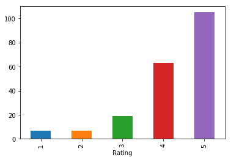

```python
rate = df.groupby('Rating').size()
rate.plot(kind='bar')
```

For every day there was a review made, what was the average rating based on the number of reviews submitted?

```python
dr = df.groupby('Date').Rating.mean()
dr = pd.DataFrame(dr)
dr.head(10)
```

| Date | Rating |
| --- | --- |
| 2015-10-14 | 5.000000 |
| 2015-10-16 | 4.000000 |
| 2015-11-03 | 3.000000 |
| 2015-11-04 | 5.000000 |
| 2015-11-10 | 5.000000 |
| 2015-12-01 | 4.000000 |
| 2015-12-13 | 3.000000 |
| 2015-12-15 | 5.000000 |
| 2016-01-04 | 4.666667 |
| 2016-01-10 | 5.000000 |

Let's find the top 3 *worst* days based on average review score

```python
dr.sort_values(by='Rating').head(3)
```

| Date | Rating |
| --- | --- |
| 2016-07-16 | 1.0 |
| 2018-04-04 | 1.0 |
| 2017-05-08 | 1.0 |

```python
print(date.loc['2016-07-16'])
print(date.loc['2017-05-08'])
print(date.loc['2018-04-04'])
```

```
Date
2016-07-16    1
Name: Rating, dtype: int64
Date
2017-05-08    1
Name: Rating, dtype: int64
Date
2018-04-04    1
Name: Rating, dtype: int64
```

**From above, the lowest three days all only had a single review submitted that resulted in the lowest possible average score of 1. Had there been a specific day with multiple reviews (>3) left resulting in a low score it could indicate that something potentially happened within the company that prompted employees to leave reviews all at once. Had there been 'an event' as described, we could then drill down and determine if it was related to a certain employment group/position or an outside event.**

## Text Analytics: All Reviews

```python
#Converting the reviews into a list of strings
review_all = df['Review'].tolist()
for i in review_all[:3]:
    print(i)
```

```
management gives notice to employee and appreciates them.  annual pay raises are given for cost of living. the offer tuition remission for your continued professional growth.
i worked as a graduate teaching assistant (gta) for 2 years with kansas state university (ksu). , a typical day at work was grading undergraduate student papers or exams, setting up computer hardware for meetings, proctoring exams in classroom, or administrative tasks in various offices., "the depar…
"i loved teaching italian at k-state.  it was four great years.  however, due to gov. brownbacks cuts in funding from the state government, the faculty of arts and sciences was especially hard hit.  my first department chair was very supportive, but he saw the writing on the wall and left.  his repl…
```

#### Top 20 Individual Words

```python
import nltk
from nltk import FreqDist, word_tokenize
from nltk.stem.porter import PorterStemmer
from nltk.stem import WordNetLemmatizer
from nltk.corpus import stopwords
import matplotlib.pyplot as plt
% matplotlib inline

# convert to string
tokens = str(review_all)

#All reviews have already been set to lowercase. If not you would delete the hash mark from the below comment and run
#tokens = tokens.lower()

#tokenization
tokens = word_tokenize(tokens)

#Lemmatization
wordnet_lemmatizer = WordNetLemmatizer()
tokens = (wordnet_lemmatizer.lemmatize(word) for word in tokens)

#Remove stopwords
tokens = (word for word in tokens if word not in stopwords.words('english'))

#Adding custom stopwords to be removed based on the context of data
add_stopwords = set(('work', 'place', 'kansas', 'state', 'university', 'student', 'students', 'wa', 'would',
                     'get', 'got', 'for', 'job', 'lot'))
extra_stoplist = set(stopwords.words('english')) | add_stopwords

tokens = (word for word in tokens if word not in extra_stoplist)
# Filter non-alphanumeric characters from tokens
tokens = (word for word in tokens if word.isalpha())

#remove short words
tokens = [ word for word in tokens if len(word) >= 2 ]

#Create your bigrams to be utilized later, these will provide more context to the reviews
bgs = nltk.bigrams(tokens)

#compute frequency distribution for top 20 single words
fdist_all = nltk.FreqDist(tokens)
fdist_all.most_common(20)
```

```
[('great', 67),
 ('time', 45),
 ('working', 45),
 ('good', 34),
 ('part', 33),
 ('people', 31),
 ('opportunity', 30),
 ('day', 29),
 ('experience', 29),
 ('management', 29),
 ('environment', 29),
 ('research', 28),
 ('hour', 26),
 ('pay', 25),
 ('staff', 23),
 ('position', 22),
 ('kansa', 21),
 ('make', 21),
 ('teaching', 20),
 ('benefit', 20)]
```

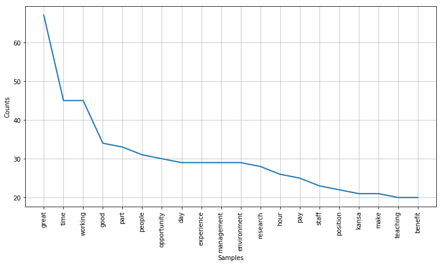

```python
plt.figure(figsize=(12,6))
fdist_all.plot(20)
```

#### Top 20 TRI-gram Pairs

```python
# convert to string
tokens = str(review_all)

#All reviews have already been set to lowercase. If not you would delete the hash mark from the below comment and run
#tokens = tokens.lower()

#tokenization
tokens = word_tokenize(tokens)

#Lemmatization
wordnet_lemmatizer = WordNetLemmatizer()
tokens = (wordnet_lemmatizer.lemmatize(word) for word in tokens)

#Remove stopwords
tokens = (word for word in tokens if word not in stopwords.words('english'))

#Adding custom stopwords to be removed based on the context of data
#Note: Not adding as many stopwords to provide more succinct context when it comes to adjectives/adverbs/nouns
add_stopwords2 = set(('place', 'kansas', 'state', 'university', 'student', 'students', 'wa', 'would',
                     'get', 'got', 'for', 'job', 'work'))
extra_stoplist2 = set(stopwords.words('english')) | add_stopwords2

tokens = (word for word in tokens if word not in extra_stoplist2)

# Filter non-alphanumeric characters from tokens
tokens = (word for word in tokens if word.isalpha())

#remove short words
tokens = [ word for word in tokens if len(word) >= 2 ]

#TRIGRAMS to be utilized later, these will provide more context to the reviews
tgs = nltk.trigrams(tokens)

#compute frequency distribution for top 20 single words
fdist_tri = nltk.FreqDist(tgs)
fdist_tri.most_common(20)
```

```
[(('graduate', 'teaching', 'assistant'), 4),
 (('hardest', 'part', 'working'), 3),
 (('worked', 'graduate', 'teaching'), 2),
 (('staff', 'hardest', 'part'), 2),
 (('rust', 'resistant', 'gene'), 2),
 (('long', 'period', 'time'), 2),
 (('definitely', 'recommend', 'looking'), 2),
 (('recommend', 'looking', 'type'), 2),
 (('looking', 'type', 'position'), 2),
 (('type', 'position', 'graduate'), 2),
 (('typical', 'day', 'consists'), 2),
 (('person', 'created', 'position'), 2),
 (('go', 'back', 'school'), 2),
 (('graduate', 'research', 'assistant'), 2),
 (('give', 'notice', 'employee'), 1),
 (('notice', 'employee', 'appreciates'), 1),
 (('employee', 'appreciates', 'annual'), 1),
 (('appreciates', 'annual', 'pay'), 1),
 (('annual', 'pay', 'raise'), 1),
 (('pay', 'raise', 'given'), 1)]
```

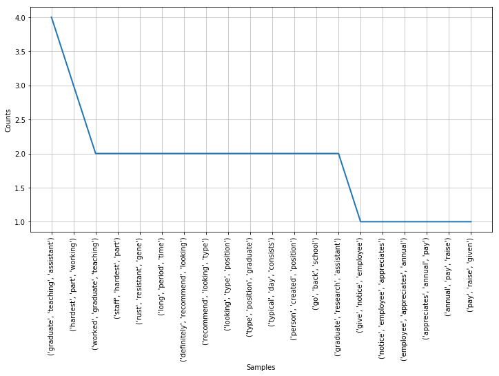

```python
plt.figure(figsize=(12,6))
fdist_tri.plot(20)
```

**Regarding the tri-grams, I wanted to see potentially-common phrases used in each review to see if there was something regularly coming up. Aside from many people stating their job title in the text of the review (even though it already displays it for them at the top of the review in a separate field), it seems that the most common phrases centered around the "hardest part about working" at the university, the duration of employment, and a typical day's duties.**

# Drilling down further based on Title of the reviewer

```python
df.Title.value_counts().head(10)
```

```
graduate teaching assistant          10
graduate research assistant           9
research assistant                    9
undergraduate research assistant      6
undergraduate researcher              3
custodian                             3
graduate teaching assistant (gta)     3
research associate                    2
student employee                      2
office assistant                      2
Name: Title, dtype: int64
```

It appears most reviews were written by GTA/GRAs and Undergraduate Research Assistants. Because of the high variability in how the data was entered (e.g. 'GTA' vs. 'Graduate Teaching Assistant'), it would be useful to try and more accurately aggregate identical titles while accounting for data-entry differences

```python
df[df['Title'].str.contains("graduate teaching assistant|gta", na=False)].shape
```

```
(14, 5)
```

There are actually 14 Graduate Teaching Assistant reviews instead of just 10 when we aggregate this way. This would provide a more accurate analysis of the reviews. Potential issues still arise from general titles such as student employee, research associate (not indicative of what capacity), and colloquials such as "custodian" vs. "maintenance" vs. "janitor". Let's drill down into the reviews left by anyone in a research-based capacity.

## Drilling down into reviews based on those who possess a research-based Title.

```python
research = df[df['Title'].str.contains("research", na=False)]
research['Title'].count()
#There are 43 reviews of the 201 that are from individuals who work in research at the University
```

```
43
```

```python
df['Rating'].count()
```

```
201
```

```python
#This could be developed into a scalable function for future use
(research['Title'].count() / df['Rating'].count() * 100)
```

```
21.393034825870647
```

**21% of the reviews left by people on Indeed.com for Kansas State University work in a research-based capacity.** This is a fairly large distribution of people who feel strongly enough to leave a review. Let's go a bit deeper and examine the average ratings they have left

```python
research['Rating'].describe()
```

```
count    43.000000
mean      4.395349
std       1.026773
min       1.000000
25%       4.000000
50%       5.000000
75%       5.000000
max       5.000000
Name: Rating, dtype: float64
```

Wow - an overwhelmingly positive sample of reviews for those working in research. An average rating of 4.39! Let's find out what makes it so good...or bad!

## Text Analytics of the reviews left by researchers

```python
review_r = research['Review'].tolist()
for i in review_r[:3]:
    print(i)
```

```
good research and study environment. no traffic jam. sometimes, need work at night shifts, but usually no need to work overtime. i have good memory about this university.
skillfully focused on wheat and developing molecular markers for marker-assisted selection (mas), specifically the molecular characterization of disease resistance genes, and by using molecular techniques, identified a strand of rust resistant genes in a wild relative of wheat. arduously developed a…
i was a research assistant at kansas state for approximately six months. during my time there i was given the opportunity to gain experience in a variety of areas.
```

```python
# convert to string
tokens = str(review_r)

#All reviews have already been set to lowercase. If not you would delete the hash mark from the below comment and run
#tokens = tokens.lower()

#tokenization
tokens = word_tokenize(tokens)

#Lemmatization
wordnet_lemmatizer = WordNetLemmatizer()
tokens = (wordnet_lemmatizer.lemmatize(word) for word in tokens)

#Remove stopwords
tokens = (word for word in tokens if word not in stopwords.words('english'))

#Adding custom stopwords to be removed based on the context of data
add_stopwords = set(('work', 'place', 'kansas', 'state', 'university', 'student', 'students', 'wa', 'would',
                     'get', 'got', 'for', 'job', 'lot'))
extra_stoplist = set(stopwords.words('english')) | add_stopwords

tokens = (word for word in tokens if word not in extra_stoplist)
# Filter non-alphanumeric characters from tokens
tokens = (word for word in tokens if word.isalpha())

#remove short words
tokens = [ word for word in tokens if len(word) >= 2 ]

#Create your bigrams to be utilized later, these will provide more context to the reviews
bgs = nltk.bigrams(tokens)

#compute frequency distribution for top 20 single words
fdist_r = nltk.FreqDist(tokens)
fdist_r.most_common(20)
```

```
[('research', 20),
 ('good', 12),
 ('opportunity', 12),
 ('kansa', 10),
 ('great', 10),
 ('environment', 8),
 ('time', 7),
 ('nice', 7),
 ('working', 7),
 ('hour', 6),
 ('graduate', 6),
 ('part', 6),
 ('need', 5),
 ('make', 5),
 ('management', 5),
 ('learned', 5),
 ('campus', 5),
 ('new', 5),
 ('school', 5),
 ('help', 5)]
```

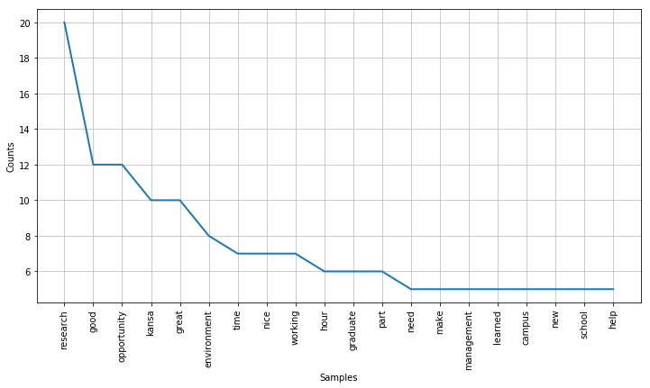

```python
plt.figure(figsize=(12,6))
fdist_r.plot(20)
```

```python
# convert to string
tokens = str(review_r)

#All reviews have already been set to lowercase. If not you would delete the hash mark from the below comment and run
#tokens = tokens.lower()

#tokenization
tokens = word_tokenize(tokens)

#Lemmatization
wordnet_lemmatizer = WordNetLemmatizer()
tokens = (wordnet_lemmatizer.lemmatize(word) for word in tokens)

#Remove stopwords
tokens = (word for word in tokens if word not in stopwords.words('english'))

#Adding custom stopwords to be removed based on the context of data
#Note: Not adding as many stopwords to provide more succinct context when it comes to adjectives/adverbs/nouns
add_stopwords2 = set(('place', 'kansas', 'state', 'university', 'student', 'students', 'wa', 'would',
                     'get', 'got', 'for', 'job', 'work'))
extra_stoplist2 = set(stopwords.words('english')) | add_stopwords2

tokens = (word for word in tokens if word not in extra_stoplist2)

# Filter non-alphanumeric characters from tokens
tokens = (word for word in tokens if word.isalpha())

#remove short words
tokens = [ word for word in tokens if len(word) >= 2 ]

#TRIGRAMS to be utilized later, these will provide more context to the reviews
tgs = nltk.trigrams(tokens)

#compute frequency distribution for top 20 single words
fdist_tri = nltk.FreqDist(tgs)
fdist_tri.most_common(20)
```

```
[(('rust', 'resistant', 'gene'), 2),
 (('graduate', 'research', 'assistant'), 2),
 (('research', 'study', 'environment'), 1),
 (('study', 'environment', 'traffic'), 1),
 (('environment', 'traffic', 'jam'), 1),
 (('traffic', 'jam', 'sometimes'), 1),
 (('jam', 'sometimes', 'need'), 1),
 (('sometimes', 'need', 'night'), 1),
 (('need', 'night', 'shift'), 1),
 (('night', 'shift', 'usually'), 1),
 (('shift', 'usually', 'need'), 1),
 (('usually', 'need', 'overtime'), 1),
 (('need', 'overtime', 'good'), 1),
 (('overtime', 'good', 'memory'), 1),
 (('good', 'memory', 'focused'), 1),
 (('memory', 'focused', 'wheat'), 1),
 (('focused', 'wheat', 'developing'), 1),
 (('wheat', 'developing', 'molecular'), 1),
 (('developing', 'molecular', 'marker'), 1),
 (('molecular', 'marker', 'selection'), 1)]
```

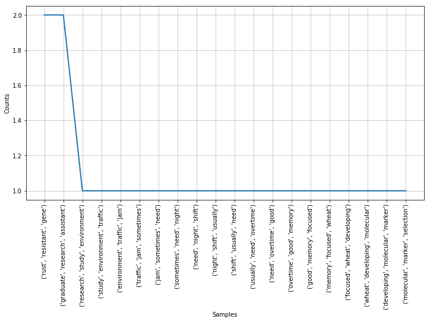

```python
plt.figure(figsize=(12,6))
fdist_tri.plot(20)
```

**I had hoped that the research based reviews provided a bit more specific insight, as both individual and trigram lists generated don't provide a whole lot. The trigram data for the research reviews does give a picture into what kind of research is being done, and could be an indicator for those departments the reviews are coming from (i.e. wheat developing and molecular markers...etc)**